# Week 4, Meeting 1

# NumPy

## What is NumPy?

https://numpy.org/doc/stable/user/whatisnumpy.html

- NumPy is THE fundamental package for scientific computing in Python.
- It is a Python library that provides a multidimensional array object (from which we derive matrices)
- AND routines for fast operations on arrays
  - mathematics
  - shape manipulation,
  - sorting,
  - basic linear algebra,
  - basic statistical operations etc

## How does it work

- NumPy has the ndarray object.
- This object is an **n-dimensional array** of homogeneous data types (atomic, like vectors and matrices in R),
- Its operations are a mix of Python and compiled code (primarily C and C++ but also Fortran) for performance purposes.
- NumPy’s operations on ndarrays are estimated to be over 100 times faster than a list comprehension and the bigger the data gets, the bigger the ndarray advantage.

## Differences

There are several important differences between NumPy arrays and the standard Python sequences:

- NumPy arrays are fixed‑size — once you allocate an ndarray, its total number of elements doesn’t change like a list can.
- A NumPy ndarray allocates one contiguous block of memory sized exactly for its number of elements

```python
import numpy as np
a = np.arange(5)
b = list(range(5))
print(f'NumPy ndarray a: {a}, id: {id(a)}')
print(f'List b: {b}, id: {id(b)}')
a = np.append(a, 5)
b.append(5)
print(f'NumPy ndarray a: {a}, id: {id(a)}')
print(f'List b: {b}, id: {id(b)}')
```

```
NumPy ndarray a: [0 1 2 3 4], id: 4780838320
List b: [0, 1, 2, 3, 4], id: 4354569728
NumPy ndarray a: [0 1 2 3 4 5], id: 4780838704
List b: [0, 1, 2, 3, 4, 5], id: 4354569728
```

Increasing the size an array (np.append, np.concatenate, np.resize) always returns a new array.

## More Differences and Details

- With some exceptions (e.g., an array of references), all elements in a NumPy array are all required to be of the same data type, resulting in all elements having the same size in memory.
  - But if you want to capitalize on its speed and memory efficiency, use a numeric dtype (e.g. float, int).
  - If you mix type, NumPy will pick a single data type that can represent all of the values and convert your data. This is called “upcasting” (coercion)

```python
x = np.array([1, 2, 3])        # dtype int64
print(f'x is {x} dtype is {x.dtype}  which needs {x.itemsize} bytes per element')
y = np.array([1. , 2, 3])      # dtype float64 (int changed to float)
print(f'y is {y} dtype is {y.dtype}  which needs {y.itemsize} bytes per element')
z = np.array([1, 2.0, 3+0j])   # dtype complex128 (int and float changed)
print(f'z is {z} dtype is {z.dtype}  which needs {z.itemsize} bytes per element')
a = np.array([1, 2.0, 3+0j, 'x']) # dtype '<U21'  (all elements become Unicode)
print(f'a is {a} dtype is {a.dtype} which needs {a.itemsize} bytes per element')
```

```
x is [1 2 3] dtype is int64  which needs 8 bytes per element
y is [1. 2. 3.] dtype is float64  which needs 8 bytes per element
z is [1.+0.j 2.+0.j 3.+0.j] dtype is complex128  which needs 16 bytes per element
a is ['1' '2.0' '(3+0j)' 'x'] dtype is <U64 which needs 256 bytes per element
```

## Additional Details

- NumPy arrays are always rectangular.
- NumPy arrays facilitate advanced mathematical and other types of operations on large data. Execution is more efficient with less code than standard Python.
- To get the most out of the scientific/mathematical Python-based libraries you must know how to use NumPy arrays (standard Python is not enough)
- pandas, matplotlib, scipy, statsmodels, Scikit-learn (ML), OpenCV…

## Multiplication Example (Standard vs Numpy)

```python
a = [1, 2, 3, 4]
b = [10, 20, 30, 40]

c = []
for i in range(len(a)):
    c.append(a[i] * b[i])

print(f'This is {c}')
print(f'its type is {type(c)}')
print(f'it has length {len(c)}')
```

```
This is [10, 40, 90, 160]
its type is <class 'list'>
it has length 4
```

```python
import numpy as np

a = np.array([1, 2, 3, 4])
b = np.array([10, 20, 30, 40])

c = a * b
# element‑wise multiplication
print(f'This is {c}')
print(f'its type is {type(c)}')
print(f'it is a {c.ndim}D array of size')
print(f'{c.size} with shape {c.shape}')
```

```
This is [ 10  40  90 160]
its type is <class 'numpy.ndarray'>
it is a 1D array of size
4 with shape (4,)
```

## Vectorization

- means no explicit looping, indexing, etc., in your Python/NumPy code
- all this is happening in optimized, pre-compiled C code.
- vectorized code is more concise and easier to read
- result *should be* fewer mistakes
- looks like standard mathematical notation (should be easier to code the math in NumPy)
- Vectorization is “Pythonic” and will remind you of R

## Recall R

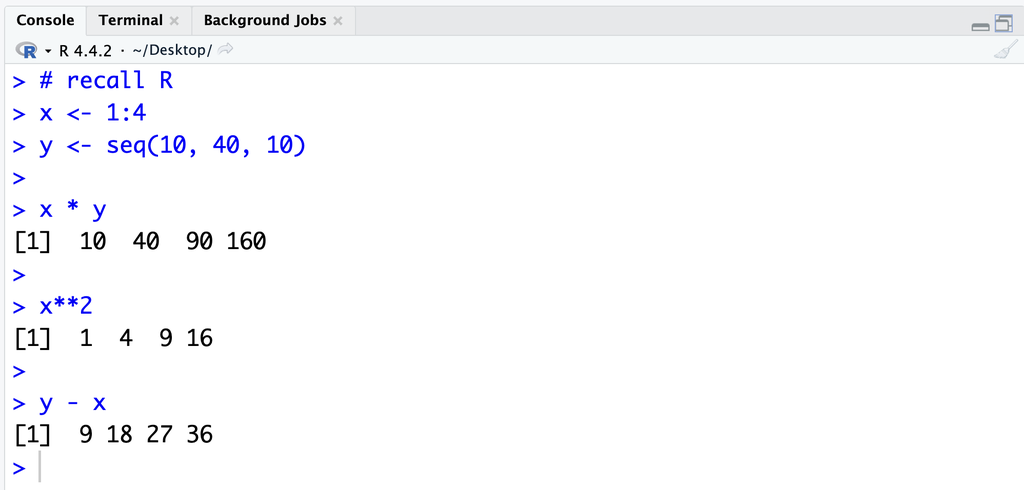

## A mental exercise, please

- You can try it for real with in your team in a few minutes

```python
import numpy as np

a = np.array(range(1, 11))
b = np.array((10, 20, 30, 40, 50, 60, 70, 80, 90, 100))

## try squaring a
a_squared = None
print(a_squared)

## try subtracting b from a
print()

## try multiply a and b
print()

## try it, but we may need a little more guidance
##  before we can produce multiplication chart from a

print(a.shape)
print(a.ndim)
```

```
None


(10,)
1
```

## The most natural “way”

- Numpy uses Python’s built‑in operators
- https://docs.python.org/3/library/operator.html#mapping-operators-to-functions

```python
a = np.array([1, 2, 3])
b = np.array([4, 5, 6])

print(f'a + b result {a + b}')
print(f'a - b result {a - b}')
print(f'a * b result {a * b}')
print(f'a / b result {a / b}')
print(f'a**b result {a ** b}')
```

```
a + b result [5 7 9]
a - b result [-3 -3 -3]
a * b result [ 4 10 18]
a / b result [0.25 0.4  0.5 ]
a**b result [  1  32 729]
```

## Also supports functional and OOP styles

- Numpy has “ufuncs” (universal functions) which utilize vectorization and have a “built-in” feel: https://numpy.org/doc/stable/reference/ufuncs.html

```python
a = np.array([1, 2, 3])
b = np.array([4, 5, 6])

print(f'a is {a} a {a.ndim}D array of size {a.size} with shape {a.shape}')
print(f'b is {b} a  {b.ndim}D array of size {b.size} with shape {b.shape}')

# Functional style
a_plus_b = np.add(a, b) # a + b
a_less_b = np.subtract(a, b) # a - b
a_times_b = np.multiply(a, b) # a * b
a_divide_b = np.divide(a, b) # a / b

print(f'np.add(a, b) result {a_plus_b}')
print(f'np.subtract(a, b) result {a_less_b}')
print(f'np.multiply(a, b) result {a_times_b}')
print(f'np.divide(a, b) result {a_divide_b}')
```

```
a is [1 2 3] a 1D array of size 3 with shape (3,)
b is [4 5 6] a  1D array of size 3 with shape (3,)
np.add(a, b) result [5 7 9]
np.subtract(a, b) result [-3 -3 -3]
np.multiply(a, b) result [ 4 10 18]
np.divide(a, b) result [0.25 0.4  0.5 ]
```

```python
a = np.array([1, 2, 3])
b = np.array([4, 5, 6])

# OOP style - method
a_plus_b = a.__add__(b) #   a + b
a_less_b = a.__sub__(b) #  a - b
a_times_b = a.__mul__(b) # a * b
a_divide_b = a.__truediv__(b) # a / b

print(f'a.__add__(b) result {a_plus_b}')
print(f'a.__sub__(b) result {a_less_b}')
print(f'a.__mul__(b) result {a_times_b}')
print(f'a.__truediv__(b) result {a_divide_b}')
```

```
a.__add__(b) result [5 7 9]
a.__sub__(b) result [-3 -3 -3]
a.__mul__(b) result [ 4 10 18]
a.__truediv__(b) result [0.25 0.4  0.5 ]
```

## (recall) Class, methods, attributes

All of this in one little object…

```python
methods = []
attributes = []

for name in dir(a):
    try:
        if hasattr(a, name):  # Safe check
            attr = getattr(a, name)
        if callable(attr):
            methods.append(name)
        else:
            attributes.append(name)
    except (AttributeError, ValueError) as e:
        print(f"Skipped {name}: {e}")

print("Methods:")
print(methods)

print("\nAttributes:")
print(attributes)
```

```
Skipped mT: matrix transpose with ndim < 2 is undefined
Methods:
['__abs__', '__add__', '__and__', '__array__', '__array_finalize__', '__array_function__', '__array_namespace__', '__array_ufunc__', '__array_wrap__', '__bool__', '__buffer__', '__class__', '__class_getitem__', '__complex__', '__contains__', '__copy__', '__deepcopy__', '__delattr__', '__delitem__', …

Attributes:
['T', '__array_interface__', '__array_priority__', '__array_struct__', '__doc__', '__hash__', 'base', 'ctypes', 'data', 'device', 'dtype', 'flags', 'flat', 'imag', 'itemsize', 'nbytes', 'ndim', 'newbyteorder', 'real', 'shape', 'size', 'strides']
```

## (aside) R and library()

- In R, third-party libraries are managed very well (left side)
- But you could call libraries in R like Python (right side)

```python
library(ggplot2)
ggplot(data = iris,
       aes(x = Sepal.Length,
           y = Sepal.Width,
           color = Species)) +
  geom_point()
```

```python
ggplot2::ggplot(data = iris,
                ggplot2::aes(x = Sepal.Length,
                             y = Sepal.Width,
                             color = Species)) +
  ggplot2::geom_point()
```

# Activity

## What to do in your group (5-10 minutes)

Grab a team photo, and then

- Please check your team
  - does everyone have NumPy working?
  - extra - how about pandas and matplotlib?
  - pretty much anything Python related that your team can agree upon
  - the most important lesson to come away with from being here is how to interact with your classmates

# NumPy Basics

## Basic difference Example

```python
a = np.array(range(6))
b = np.array([0, 1, 2, 3, 4, 5])
c = np.array((0, 1, 2, 3, 4, 5))

print(f"This is a: {a}")
print(f"size :{a.size}, shape :{a.shape}, dimension: {a.ndim}, dtype:{a.dtype}")
print(f"This is b: {b}")
print(f"size :{b.size}, shape :{b.shape}, dimension: {b.ndim}, dtype:{b.dtype}")
print(f"This is c: {c}")
print(f"size :{c.size}, shape :{c.shape}, dimension: {c.ndim}, dtype:{c.dtype}")
```

```
This is a: [0 1 2 3 4 5]
size :6, shape :(6,), dimension: 1, dtype:int64
This is b: [0 1 2 3 4 5]
size :6, shape :(6,), dimension: 1, dtype:int64
This is c: [0 1 2 3 4 5]
size :6, shape :(6,), dimension: 1, dtype:int64
```

```python
a2D = np.array([range(6)])
b2D = np.array([[0, 1, 2, 3, 4, 5]])
c2D = np.array([(0, 1, 2, 3, 4, 5)])

print(f"This is a2D: {a2D}")
print(f"size :{a2D.size}, shape :{a2D.shape}, dimension: {a2D.ndim}, dtype:{a2D.dtype}")
print(f"This is b2D: {b2D}")
print(f"size :{b2D.size}, shape :{b2D.shape}, dimension: {b2D.ndim}, dtype:{b2D.dtype}")
print(f"This is c2D: {c2D}")
print(f"size :{c2D.size}, shape :{c2D.shape}, dimension: {c2D.ndim}, dtype:{c2D.dtype}")
```

```
This is a2D: [[0 1 2 3 4 5]]
size :6, shape :(1, 6), dimension: 2, dtype:int64
This is b2D: [[0 1 2 3 4 5]]
size :6, shape :(1, 6), dimension: 2, dtype:int64
This is c2D: [[0 1 2 3 4 5]]
size :6, shape :(1, 6), dimension: 2, dtype:int64
```

## Why does it matter?

- 1D vectors (shape (6,)) are fine for simple element‑wise operations or storage.
- 2D is a row vector (shape (1,6)). Use this when thinking of your data as matrices (e.g., so that c2D @ some_matrix works as expected).
- With 2D being a list of tuples (or list of lists etc.), you get a 2D array for matrix‑style code,
- Less likely to accidently create a 1D vector. 2D is shape (n, m) rather than (m,)

## 1D vs 2D vector

- Transpose
- Broadcasting
- Example 1
- Example 2
- Example 3
- R v Python

```python
a = np.array([0, 1, 2, 3, 4, 5])
print(f'This is a: {a}')
print(f'transpose is a.T = {a.T} (no change) and its shape is {a.T.shape}')

b = np.array([[0, 1, 2, 3, 4, 5]])
print(f'This is b: {b}')
print(f'transpose is b.T = ')
print(f'{b.T}')
print(f'and b.T shape is {b.T.shape}')
```

```
This is a: [0 1 2 3 4 5]
transpose is a.T = [0 1 2 3 4 5] (no change) and its shape is (6,)
This is b: [[0 1 2 3 4 5]]
transpose is b.T =
[[0]
 [1]
 [2]
 [3]
 [4]
 [5]]
and b.T shape is (6, 1)
```

- Broadcasting is how NumPy performs operations on arrays of different shapes — without explicitly copying or expanding data.
- NumPy compares shapes right to left, aligning dimensions. It applies the following rules:
  - equivalent shapes the same operations are OK
  - one of the dimensions is 1, NumPy will “broadcast” the smaller along the larger’s dimension.
  - if neither dimension is 1 but they differ, broadcasting fails with a ValueError (incompatible)

```python
a = np.array([1, 2, 3, 4, 5, 6]) # (6,)
a2 = np.array([[1, 2, 3, 4, 5, 6]]) # (1,6)
b = 10
print(a + b)
print(a2 + b)
```

```
[11 12 13 14 15 16]
[[11 12 13 14 15 16]]
```

```python
a = np.array([1, 2, 3, 4, 5, 6])
b = np.array([10, 20, 30, 40, 50, 60])
print(a + b)  # works
print(b + a)  # same


# 2D broadcasting
a2 = np.array([[1, 2, 3, 4, 5, 6]]) # (1,6)
b2 = np.array([[7], [8], [9], [10], [11], [12]]) # (6,1)
print(a2 + b2)
# print(b2 + a2) # same
print(a + a2)
print(a + b2)
```

```
[11 22 33 44 55 66]
[11 22 33 44 55 66]
[[ 8  9 10 11 12 13]
 [ 9 10 11 12 13 14]
 [10 11 12 13 14 15]
 [11 12 13 14 15 16]
 [12 13 14 15 16 17]
 [13 14 15 16 17 18]]
[[ 2  4  6  8 10 12]]
[[ 8  9 10 11 12 13]
 [ 9 10 11 12 13 14]
 [10 11 12 13 14 15]
 [11 12 13 14 15 16]
 [12 13 14 15 16 17]
 [13 14 15 16 17 18]]
```

```python
print(a * b)  # works
print(b * a)  # same

print(a2 * b2) # 6 x 6
print(a * a2) # 1 x 6
print(a * b2) # 6 x 6
```

```
[ 10  40  90 160 250 360]
[ 10  40  90 160 250 360]
[[ 7 14 21 28 35 42]
 [ 8 16 24 32 40 48]
 [ 9 18 27 36 45 54]
 [10 20 30 40 50 60]
 [11 22 33 44 55 66]
 [12 24 36 48 60 72]]
[[ 1  4  9 16 25 36]]
[[ 7 14 21 28 35 42]
 [ 8 16 24 32 40 48]
 [ 9 18 27 36 45 54]
 [10 20 30 40 50 60]
 [11 22 33 44 55 66]
 [12 24 36 48 60 72]]
```

R makes shorter vectors the same length as longer vectors by using “recycling.” Python does not recycle.

| Feature | R | NumPy |
| --- | --- | --- |
| Element recycling | Yes | Error |
| Broadcasting behavior | Not applicable | Yes |
| Warning when mismatched? | Sometimes | Error |

## More NumPy NDarrays

- 2D column vector (transpose) and 2D array (matrix)

```python
a_T = np.array([range(6)]).T
b_T = np.array([[0, 1, 2, 3, 4, 5]]).T
c_T = np.array([(0, 1, 2, 3, 4, 5)]).T

print(f"a_T is size :{a_T.size}, shape :{a_T.shape}, dimension: {a_T.ndim}, dtype:{a_T.dtype}")
print(f"b_T is size :{b_T.size}, shape :{b_T.shape}, dimension: {b_T.ndim}, dtype:{b_T.dtype}")
print(f"c_T is size :{c_T.size}, shape :{c_T.shape}, dimension: {c_T.ndim}, dtype:{c_T.dtype}")

print(f"Example b_T is")
print(f"{b_T}")
print(f"and b_T[::2] is")
print(f"{b_T[::2]}")
```

```
a_T is size :6, shape :(6, 1), dimension: 2, dtype:int64
b_T is size :6, shape :(6, 1), dimension: 2, dtype:int64
c_T is size :6, shape :(6, 1), dimension: 2, dtype:int64
Example b_T is
[[0]
 [1]
 [2]
 [3]
 [4]
 [5]]
and b_T[::2] is
[[0]
 [2]
 [4]]
```

```python
a = np.array([[1, 2, 3, 4, 5, 6],[7, 8, 9, 10, 11, 12],
[13, 14, 15, 16, 17, 18],[19, 20, 21, 22, 23, 24]])

print(f"a is size :{a.size}, shape :{a.shape}, dimension: {a.ndim}, dtype:{a.dtype}")
print(f"a[1][4] is {a[1][4]}")
print(f"and this is a:")
print(f"{a}")
```

```
a is size :24, shape :(4, 6), dimension: 2, dtype:int64
a[1][4] is 11
and this is a:
[[ 1  2  3  4  5  6]
 [ 7  8  9 10 11 12]
 [13 14 15 16 17 18]
 [19 20 21 22 23 24]]
```

## Higher Dimensions

3D and 4D arrays (and of course beyond)

```python
# A 3×2×4 array: 3 “blocks” of 2×4 matrices
a = np.array([
    [  # block 0
      [1., 2., 3., 4.],
      [5., 6., 7., 8.]
    ],
    [  # block 1
      [ 9., 10.,11.,12.],
      [13.,14.,15.,16.]
    ],
    [  # block 2
      [17.,18.,19.,20.],
      [21.,22.,23.,24.]
    ]
])
print(f"a is size :{a.size}, shape :{a.shape}, dimension: {a.ndim}, dtype:{a.dtype}")
print(a[1][0][2]) # 11
print(a)
```

```
a is size :24, shape :(3, 2, 4), dimension: 3, dtype:float64
11.0
[[[ 1.  2.  3.  4.]
  [ 5.  6.  7.  8.]]

 [[ 9. 10. 11. 12.]
  [13. 14. 15. 16.]]

 [[17. 18. 19. 20.]
  [21. 22. 23. 24.]]]
```

```python
b = np.array([
    [
      [[1, 2], [3, 4]],
      [[5, 6], [7, 8]]
    ],
    [
      [[9, 10],[11,12]],
      [[13,14],[15,16]]
    ],
    [
      [[17,18],[19,20]],
      [[21,22],[23,24]]
    ]
])
print(f"b is size :{b.size}, shape :{b.shape}, dimension: {b.ndim}, dtype:{b.dtype}")

print()
print(b)

print()
print(f"b[1][0][1][0] is {b[1][0][1][0]} scalar")
print(f"b[1][0][1] is {b[1][0][1]} vector")
print(f"b[1][0] is {b[1][0]} matrix")
print(f"b[1] is {b[1]} block/tensor/volume")
```

```
b is size :24, shape :(3, 2, 2, 2), dimension: 4, dtype:int64

[[[[ 1  2]
   [ 3  4]]

  [[ 5  6]
   [ 7  8]]]


 [[[ 9 10]
   [11 12]]

  [[13 14]
   [15 16]]]


 [[[17 18]
   [19 20]]

  [[21 22]
   [23 24]]]]

b[1][0][1][0] is 11 scalar
b[1][0][1] is [11 12] vector
b[1][0] is [[ 9 10]
 [11 12]] matrix
b[1] is [[[ 9 10]
  [11 12]]

 [[13 14]
  [15 16]]] block/tensor/volume
```

## Vocabulary (might help)

The authors/maintainers of NumPy don’t like to use this vocabulary but if it helps you, then do.

- 0‑D array is a scalar
- 1‑D array is a vector
- 2‑D array is a matrix
- 3‑D array is commonly called a 3rd‑order tensor
- 4‑D array and higher are n‑D arrays or an nth‑order tensor

## Additional Basic Functions

- np.zeros(), np.ones()
- default is float, but can be changed.

```python
a = np.zeros(12).reshape(3, 4)
b = np.ones(24).reshape(2, 3, 4)
print('a is np.zeros(12).reshape(3, 4)')
print(a)
print()
print('a is np.ones(24).reshape(2, 3, 4)')
print(b)
```

```
a is np.zeros(12).reshape(3, 4)
[[0. 0. 0. 0.]
 [0. 0. 0. 0.]
 [0. 0. 0. 0.]]

a is np.ones(24).reshape(2, 3, 4)
[[[1. 1. 1. 1.]
  [1. 1. 1. 1.]
  [1. 1. 1. 1.]]

 [[1. 1. 1. 1.]
  [1. 1. 1. 1.]
  [1. 1. 1. 1.]]]
```

## Additional Basic Functions (cont’d)

- np.full(), np.random(), np.arange()

```python
a_full = np.full((3, 4), 7)
b_random = np.random.randint(1, 100, (3, 4))
c_arange = np.arange(1, 25).reshape(2, 3, 4)

print(f'this is a_full, forcing it to 2D')
print(f'np.full((3, 4), 7)')
print(f'{a_full}')
```

```
this is a_full, forcing it to 2D
np.full((3, 4), 7)
[[7 7 7 7]
 [7 7 7 7]
 [7 7 7 7]]
```

```python
print('this is b_random also 2D 3,4')
print('np.random.randint(1, 100, (3, 4))')
print(f"{b_random}")
print()
print('this is c_arange using the reshape method')
print('np.arange(1, 25).reshape(2, 3, 4)')
print(f'{c_arange}')
```

```
this is b_random also 2D 3,4
np.random.randint(1, 100, (3, 4))
[[68 56 88 42]
 [50 23 57 79]
 [17 59 17 20]]

this is c_arange using the reshape method
np.arange(1, 25).reshape(2, 3, 4)
[[[ 1  2  3  4]
  [ 5  6  7  8]
  [ 9 10 11 12]]

 [[13 14 15 16]
  [17 18 19 20]
  [21 22 23 24]]]
```

## np.linspace()

- You can also use np.linspace() to create an array with values that are spaced linearly in a specified interval.
- Results in a predictable, even spacing of numeric values for use in plotting, sampling, numerical methods, etc.

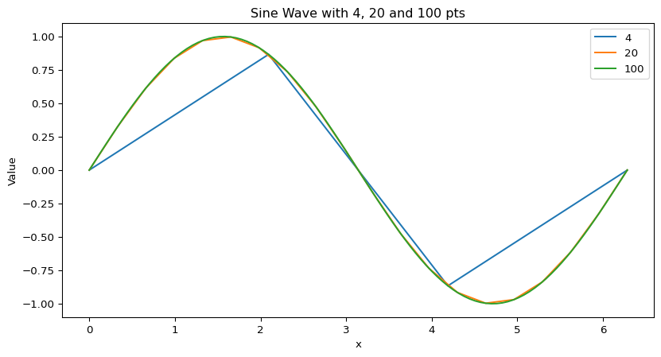

```python
import numpy as np
import matplotlib.pyplot as plt

x0 = np.linspace(0, 2*np.pi, 4)    # 4 points from 0 to 2π
x1 = np.linspace(0, 2*np.pi, 20)    # 20 points from 0 to 2π
x2 = np.linspace(0, 2*np.pi, 100)    # 100 points from 0 to 2π
y0 = np.sin(x0)
y1 = np.sin(x1)
y2 = np.sin(x2)

plt.plot(x0, y0, label='4')
plt.plot(x1, y1, label='20')
plt.plot(x2, y2, label='100')

# Labels and legend
plt.title("Sine Wave with 4, 20 and 100 pts")
plt.xlabel("x")
plt.ylabel("Value")
plt.legend()

plt.show()
```

## matplotlib

- for visualization
- about 2 weeks from now
- import matplotlib.pyplot as plt is Matlab in Python
- need plot() with a ; at minimum in Jupyter/Quarto

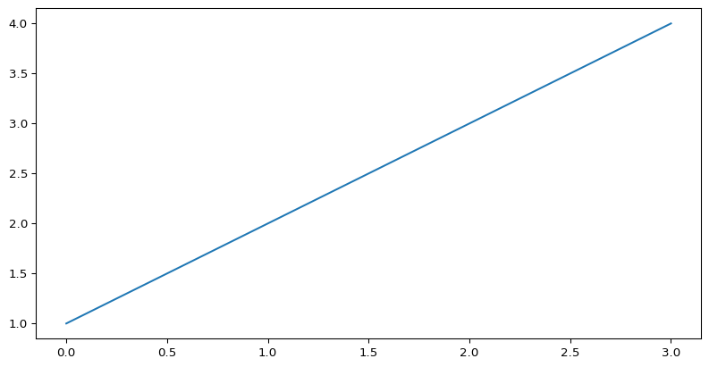

```python
import matplotlib.pyplot as plt

plt.plot([1, 2, 3, 4]);
# plt.show() # in the REPL
```

## 2D array creation functions

```python
# equivalent of a 1 in math M * I = I * M = M where M is square
# useful for solving systems of equations
# identity matrix is what you get when you multiply a matrix by its inverse
a = np.eye(4)
a_4x6 = np.eye(4, 6)
a_4x6_1 = np.eye(4, 6, k = 1) # offset

print(f"np.eye(4)")
print(a)
print(f"np.eye(4, 6)")
print(a_4x6)
print(f"np.eye(4, 6, k = 1)")
print(a_4x6_1)
```

```
np.eye(4)
[[1. 0. 0. 0.]
 [0. 1. 0. 0.]
 [0. 0. 1. 0.]
 [0. 0. 0. 1.]]
np.eye(4, 6)
[[1. 0. 0. 0. 0. 0.]
 [0. 1. 0. 0. 0. 0.]
 [0. 0. 1. 0. 0. 0.]
 [0. 0. 0. 1. 0. 0.]]
np.eye(4, 6, k = 1)
[[0. 1. 0. 0. 0. 0.]
 [0. 0. 1. 0. 0. 0.]
 [0. 0. 0. 1. 0. 0.]
 [0. 0. 0. 0. 1. 0.]]
```

```python
b = np.diag([1, 2, 3, 4])
b_1 = np.diag([1, 2, 3, 4], k = -1)

print(f"np.diag([1, 2, 3, 4])")
print(b)
print(f"np.diag([1, 2, 3, 4], k = -1)")
print(b_1)
```

```
np.diag([1, 2, 3, 4])
[[1 0 0 0]
 [0 2 0 0]
 [0 0 3 0]
 [0 0 0 4]]
np.diag([1, 2, 3, 4], k = -1)
[[0 0 0 0 0]
 [1 0 0 0 0]
 [0 2 0 0 0]
 [0 0 3 0 0]
 [0 0 0 4 0]]
```

## axis

In NumPy, axis specifies the dimension(s) over which an operation is performed. The array’s shape points to axis:

- A 1‑D array of shape (6,) has axis 0 only.
- A 2‑D array of shape (4,6) has axis 0 (length 4) and axis 1 (length 6).
- A 3‑D array of shape (3,2,4) has axis 0 (length 3), axis 1 (length 2), and axis 2 (length 4),
- and so on for higher dimensional arrays
- axis=0 is like “down the rows” — column-wise operations and axis=1 as “across the columns” — row-wise operations

## Example using sum

```python
import numpy as np
a = np.array([
    range(1,21)
]).reshape(2,10)
print(a)
```

```
[[ 1  2  3  4  5  6  7  8  9 10]
 [11 12 13 14 15 16 17 18 19 20]]
```

```python
print('Sum on Axis=0')
print(np.sum(a, axis=0))
print('Sum on Axis=1')
print(np.sum(a, axis=1))
print('Sum the flattened array')
print(np.sum(a, axis=None))
```

```
Sum on Axis=0
[12 14 16 18 20 22 24 26 28 30]
Sum on Axis=1
[ 55 155]
Sum the flattened array
210
```

## Example using sort

```python
a = np.array([
    [  # Block 0 (a[0])
    [20, 17, 14, 19],
    [5, 10, 22,  7]
    ],
    [  # Block 1 (a[1])
    [12, 18,  9, 23],
    [11,  8,  1, 13]
    ],
    [ # Block 2 (a[2])
    [3,  24, 16,  4],
    [6,  2, 15, 21]
    ]
])
print('original')
print(a)
```

```
original
[[[20 17 14 19]
  [ 5 10 22  7]]

 [[12 18  9 23]
  [11  8  1 13]]

 [[ 3 24 16  4]
  [ 6  2 15 21]]]
```

```python
print("apologies for the typos in the original")
print('Default sort across the last axis axis = -1')
print(np.sort(a))
print('axis=1 sort across the first axis is rows within matrices')
print(np.sort(a, axis=1))
print('axis=0 sorts each r,c across the matrices')
print(np.sort(a, axis=0))
print('sort the flattened array')
print(np.sort(a, axis=None))
```

```
apologies for the typos in the original
Default sort across the last axis axis = -1
[[[14 17 19 20]
  [ 5  7 10 22]]

 [[ 9 12 18 23]
  [ 1  8 11 13]]

 [[ 3  4 16 24]
  [ 2  6 15 21]]]
axis=1 sort across the first axis is rows within matrices
[[[ 5 10 14  7]
  [20 17 22 19]]

 [[11  8  1 13]
  [12 18  9 23]]

 [[ 3  2 15  4]
  [ 6 24 16 21]]]
axis=0 sorts each r,c across the matrices
[[[ 3 17  9  4]
  [ 5  2  1  7]]

 [[12 18 14 19]
  [ 6  8 15 13]]

 [[20 24 16 23]
  [11 10 22 21]]]
sort the flattened array
[ 1  2  3  4  5  6  7  8  9 10 11 12 13 14 15 16 17 18 19 20 21 22 23 24]
```

# Why LA

## A little linear algebra

- Linear algebra provides the mathematical language and computational tools for every modern data‐driven method in data science, machine learning and AI etc.
- Observations, data points, can be represented as vectors
- Datasets, rectangular and not, can be represented as matrices
- NumPy provides the data structures, vectorized operations, and linear‑algebra functions that let you express ML and AI algorithms exactly as matrix formulas

## Example 1

- Using NumPy to generate x,y coordinates saved as an ndarray

```python
import numpy as np
import matplotlib.pyplot as plt

# A triangle
triangle = np.array([
    [0, 1, -1, 0],     # x-coordinates
    [1, -0.5, -0.5, 1] # y-coordinates
])

print(f'This is triangle')
print(f'{triangle}')
print(f'This is triangle.shape {triangle.shape}')

# Plot using matplotlib
plt.figure(figsize=(6, 6))
plt.plot(triangle[0], triangle[1], 'bo-', label='Original Triangle')
plt.show()
```

```
This is triangle
[[ 0.   1.  -1.   0. ]
 [ 1.  -0.5 -0.5  1. ]]
This is triangle.shape (2, 4)
```

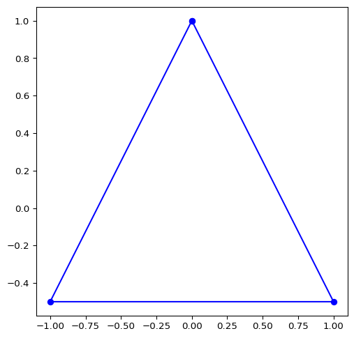

## Example 1 cont’d

- Using NumPy to construct a diagonal array
- Matrix multiply a scaling_matrix and the original triangle

```python
# Define a diagonal scaling matrix
scaling_matrix = np.diag([2, 0.5])  # Stretch x, squash y
print(f'This is the scaling_matrix')
print(f'{scaling_matrix}')
print(f'This is its dimensions: {scaling_matrix.shape}')

# transform the original
transformed_triangle = scaling_matrix @ triangle
print(f'This is the result:')
print(f'{transformed_triangle}')
```

```
This is the scaling_matrix
[[2.  0. ]
 [0.  0.5]]
This is its dimensions: (2, 2)
This is the result:
[[ 0.    2.   -2.    0.  ]
 [ 0.5  -0.25 -0.25  0.5 ]]
```

## Example 1 completed

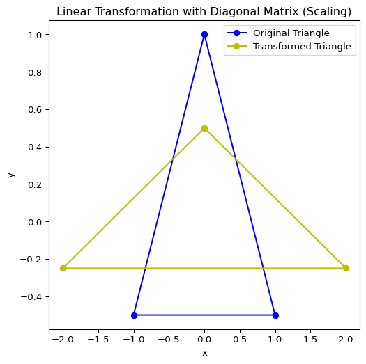

```python
# Plot together
plt.figure(figsize=(6, 6))
plt.plot(triangle[0], triangle[1], 'bo-', label='Original Triangle')
plt.plot(transformed_triangle[0], transformed_triangle[1], 'yo-', label='Transformed Triangle')
plt.title('Linear Transformation with Diagonal Matrix (Scaling)')
plt.xlabel('x')
plt.ylabel('y')
plt.legend()
plt.show()
```

## Example 1 Takeaways

- A diagonal matrix can be used to reshape ndarrays
- This is a very simplified version of the math that underlies scaling used in:
  - image filters and their fun effects
  - 3D graphics and animation.
  - machine learning for rescaling
  - sound (music) and signal processing

## Example 2

```python
# read an image

from PIL import Image
import numpy as np
import matplotlib.pyplot as plt

image_path = "meatwad.png"
image = Image.open(image_path)
image_np = np.array(image)

print(f'Shape is: {image_np.shape}')
print(f'These are two image_np[0:2, :]')
image_np[0:2, :] # two of the 836 x 4
```

```
Shape is: (688, 836, 4)
These are two image_np[0:2, :]
```

```
array([[[112, 103,  80, 255],
        [121, 109,  80, 255],
        [127, 111,  77, 255],
        ...,
        [167, 156, 115, 255],
        [168, 156, 116, 255],
        [170, 158, 119, 255]],

       [[115, 106,  83, 255],
        [123, 110,  82, 255],
        [128, 112,  78, 255],
        ...,
        [167, 156, 115, 255],
        [168, 156, 116, 255],
        [170, 158, 119, 255]]], shape=(2, 836, 4), dtype=uint8)
```

## A little background

The image is 688 (H) by 836 (W) with 4 channels

| Symbol | Channel | Range |
| --- | --- | --- |
| R | Red | 0 to 255 |
| G | Green | 0 to 255 |
| B | Blue | 0 to 255 |
| A | Alpha (transparency) | 0 (transparent) → 255 (opaque) |

So the first row of [112, 103, 80, 255] is the color and it is not transparent.

## The image in Python

[figure not shown]

```python
# Display the original image
plt.imshow(image_np)
plt.axis('off')
plt.title('Original Image')
plt.show()
```

## Modification example

- change the opacity for part of the image

```python
# Get image dimensions
height, width, _ = image_np.shape

# Desired alpha value for 30% opacity
alpha_val = int(0.3 * 255)

# Create row and column index grids
# reshape(-1, 1) 2D column vector gives N rows and 1 column.
rows = np.arange(height).reshape(-1, 1)  # shape (height, 1)
# reshape(1, -1) 2D column vector gives 1 row and N columns
cols = np.arange(width).reshape(1, -1)   # shape (1, width)

# Broadcasting the comparison to create mask
mask = rows > cols  # shape (height, width), dtype=bool

print(f'This is rows shape {rows.shape}')
print(rows[0:10,])
print(f'This is cols shape {cols.shape}')
print(cols[0, -10:])
print(f'This is mask shape {mask.shape}')
print(mask)
```

```
This is rows shape (688, 1)
[[0]
 [1]
 [2]
 [3]
 [4]
 [5]
 [6]
 [7]
 [8]
 [9]]
This is cols shape (1, 836)
[826 827 828 829 830 831 832 833 834 835]
This is mask shape (688, 836)
[[False False False ... False False False]
 [ True False False ... False False False]
 [ True  True False ... False False False]
 ...
 [ True  True  True ... False False False]
 [ True  True  True ... False False False]
 [ True  True  True ... False False False]]
```

## Slicing comment

- cols has shape (1, width) — it’s a 2D array with 1 row and width number of columns.
- cols[0] accesses the first (and only) row — results in a 1D array of column indices.
- -10: slices the last 10 elements from that row.

## Put it all together

[figure not shown]

```python
# Apply the mask to alpha (it is channel index 3)
image_np[mask, 3] = alpha_val # flattening

# Convert back to an image and display, RGBA three colors + alpha
modified_image = Image.fromarray(image_np, mode="RGBA")

plt.imshow(modified_image)
plt.axis('off')
plt.title('Lower Triangle with 30% Opacity')
plt.show()
```

## copying arrays

- return to slicing for a moment

```python
import numpy as np

x = np.arange(2, 25, 2)
print(x)
print(x.shape)

print(x[4:7])

x_2 = np.reshape(x, [3,4])
print(x_2)

print(x_2[1,3]) # returns value at row index 1, col index 3

x_2_subset = x_2[:2, :2]

print(x_2_subset)

x_2[0,0] = 1 # watch...

print(x_2_subset)
```

```
[ 2  4  6  8 10 12 14 16 18 20 22 24]
(12,)
[10 12 14]
[[ 2  4  6  8]
 [10 12 14 16]
 [18 20 22 24]]
16
[[ 2  4]
 [10 12]]
[[ 1  4]
 [10 12]]
```

## comments on the previous result

- When slicing & storing the slice - we are not creating a new independent copy of the array.
- A view of the original array x_2 is being copied to x_2_subset. We we ran:

```
x_2[0,0] = 1
```

- The change affects ANY views that include that location from x_2
- The x_2_subset[0,0] points to the same memory location as x_2[0,0] so it gets changed too.

## use .copy() to create copies

```python
x = np.arange(2, 25, 2)

x_2 = np.reshape(x, [3,4])
print(x_2)

x_2_subset_copy = x_2[:2, :2].copy()

print(x_2_subset_copy)

x_2[0,0] = 1 # this time its different

print(x_2)

print(x_2_subset_copy) # unchanged
```

```
[[ 2  4  6  8]
 [10 12 14 16]
 [18 20 22 24]]
[[ 2  4]
 [10 12]]
[[ 1  4  6  8]
 [10 12 14 16]
 [18 20 22 24]]
[[ 2  4]
 [10 12]]
```

## Views and copies are ndarrays

- and they have all the methods and attributes

```python
dir(x_2_subset)
```

[output not shown]

[output cut: 115 more lines]

[output not shown]

```python
dir(x_2_subset_copy)
```

[output not shown]

[output cut: 115 more lines]

[output not shown]

## Saving arrays

```python
np.save('meatwad_modified_array.npy', image_np)

# to read back in
image_np_reloaded = np.load('meatwad_modified_array.npy')

print('print the first few')
print(image_np_reloaded[0:3])
```

```
print the first few
[[[112 103  80 255]
  [121 109  80 255]
  [127 111  77 255]
  ...
  [167 156 115 255]
  [168 156 116 255]
  [170 158 119 255]]

 [[115 106  83  76]
  [123 110  82 255]
  [128 112  78 255]
  ...
  [167 156 115 255]
  [168 156 116 255]
  [170 158 119 255]]

 [[119 109  86  76]
  [125 112  84  76]
  [129 113  79 255]
  ...
  [167 156 115 255]
  [168 156 116 255]
  [170 158 119 255]]]
```

## Saving arrays to text and csv

- This only works for 1D or 2D arrays

```python
a = np.array([[1, 2, 3, 4, 5, 6],[7, 8, 9, 10, 11, 12],
[13, 14, 15, 16, 17, 18],[19, 20, 21, 22, 23, 24]])

# Save to a text file with default settings (space-delimited)
np.savetxt('my_a.txt', a)
# Save to a text file with delimiter = ,
np.savetxt('my_a.csv', a, delimiter=',')
```

## Result

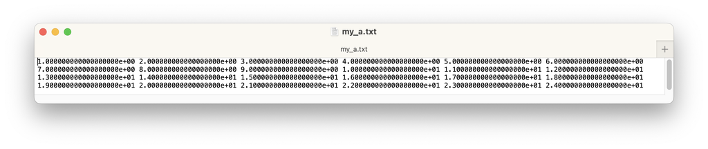

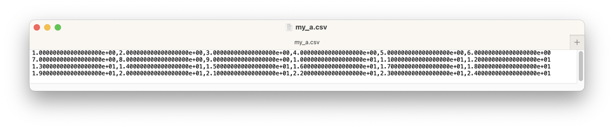